# Ames Housing Dataset: Linear Regression Model with Lasso Penalty

## Introduction

This is one of my first attempts at data analysis and predictive modelling for the Ames Housing dataset of the [*House Prices: Advanced Regression Techniques*](https://www.kaggle.com/c/house-prices-advanced-regression-techniques) training competition on Kaggle.

I chose this dataset because housing prices prediction is a very common machine learning problem used in teaching and algorithm benchmarking. [The textbook](http://www-bcf.usc.edu/~gareth/ISL/) that I used to study statistical learning features lots of examples with a pretty well-known [Boston housing dataset](http://www.cs.toronto.edu/~delve/data/boston/bostonDetail.html). The Ames Housing dataset is described on Kaggle as “a modernized and expanded version of the often cited Boston Housing dataset”. After spending quite some time working on practice problems from the textbook, creating a predictive model for the Ames Housing dataset seemed like a natural progression.

The choice of a linear regression model was due to the fact that linear models are much easier to interpret. Apart from predicting housing prices, my goal was to infer what features are important for this task. It turned out, it is hard to pinpoint what are the only important features exactly because of the presence of highly collinear predictors in the dataset and the inherent randomness of the lasso analysis method.

Nevertheless, this analysis provides a good demonstration of how the lasso works, and the final model performs quite well on the test dataset (top ~50% at the moment of writing).

## Data Preprocessing

Load the dataset.

```r
data.train <- read.csv("train.csv", header=T)
data.test <- read.csv("test.csv", header=T)
data.test$SalePrice <- 0 #Make test prices 0 for now a single data table can be created
data <- rbind(data.train, data.test)
```

### Replacing NAs

These are all the variables that have at least one missing observation.

```r
varsWithNA <- names(which(colSums(is.na(data))>0))
varsWithNA
```

```
 [1] "MSZoning"     "LotFrontage"  "Alley"        "Utilities"    "Exterior1st"  "Exterior2nd"  "MasVnrType"
 [8] "MasVnrArea"   "BsmtQual"     "BsmtCond"     "BsmtExposure" "BsmtFinType1" "BsmtFinSF1"   "BsmtFinType2"
[15] "BsmtFinSF2"   "BsmtUnfSF"    "TotalBsmtSF"  "Electrical"   "BsmtFullBath" "BsmtHalfBath" "KitchenQual"
[22] "Functional"   "FireplaceQu"  "GarageType"   "GarageYrBlt"  "GarageFinish" "GarageCars"   "GarageArea"
[29] "GarageQual"   "GarageCond"   "PoolQC"       "Fence"        "MiscFeature"  "SaleType"
```

Remove variables that are missing from >90% of all observations.

```r
names(data[colSums(is.na(data))/nrow(data) > 0.9])
```

```
[1] "Alley"       "PoolQC"      "MiscFeature"
```

```r
data["MiscFeature"] <- NULL # Missing value in 96.4% of observations
data["Alley"] <- NULL # Missing value in 93.2% of observations
data["PoolQC"] <- NULL # Missing value in 99.7% of observations
```

Divide nominal and ordinal variables that have missing values into following categories:

- Missing Observations (cannot make assumptions about the value; mark as “MissingObs”)
- Effectively Absent (assume that NA means the feature is absent; mark as “None”)

Divide continuous and discrete variables that have missing values into following categories:

- Missing Numerical Observations (cannot make assumptions about the value; mark as -1)
- Effectively Zero (assume that NA means the feature is absent, meaning effective size is 0; mark as 0)

```r
missingObs <- c("MSZoning", "MasVnrType", "Utilities", "Exterior1st", "Exterior2nd", "SaleType")
effZero <- c("LotFrontage", "MasVnrArea", "BsmtFinSF1", "BsmtFinSF2", "BsmtUnfSF", "TotalBsmtSF","GarageCars", "GarageArea", "BsmtFullBath", "BsmtHalfBath")
# Get Effectively Absent category by excluding other categories from varsWithNA
effAbsent <- varsWithNA[!varsWithNA %in% missingObs]
effAbsent <- effAbsent[!effAbsent %in% effZero]
effAbsent <- effAbsent[!effAbsent %in% c("Functional", "GarageYrBlt")]
# Function for replacing NAs in nominal and ordinal variables
replaceNAfactor = function(data.col, factorString){
  char.col <- as.character(data.col)
  char.col[which(is.na(data.col))] <- factorString
  as.factor(char.col)
}
# Replace NAs with None in Effectively Absent category
for (i in 1:ncol(data)){
  if(names(data[i]) %in% effAbsent){
    data[,i] <- replaceNAfactor(data[,i], "None")}
}
# Replace NAs with MissingObs in Missing Observations category
for (i in 1:ncol(data)){
  if(names(data[i]) %in% missingObs){
    data[,i] <- replaceNAfactor(data[,i], "MissingObs")}
}
# Replace NAs with 0 in Effectively Zero category
for (i in 1:ncol(data)){
  if(names(data[i]) %in% effZero)
    data[is.na(data[,i]),i] <- 0
}
# Replace NA with -1 in Missing Numerical Observations category
data$GarageYrBlt[is.na(data$GarageYrBlt)] <- -1
```

Variable *Functional* is a bit special. There is a following comment about this variable in the DataDocumentation.txt file:

```
Functional (Ordinal): Home functionality (Assume typical unless deductions are warranted)
```

Therefore, assume that NA for variable *Functional* means “Typ”.

```r
data$Functional <- replaceNAfactor(data$Functional, "Typ")
```

Make sure that NAs are replaced in every variable.

```r
names(which(colSums(is.na(data))>0))
```

```
character(0)
```

### Encoding Variables to Correct Types

Refer to DataDocumentation.txt for help with variable encoding.

*MSSubClass* is not a discrete variable. It is a nominal variable that identifies a type of a house.

```r
data$MSSubClass <- as.factor(data$MSSubClass)
```

There are 22 ordinal variables in the dataset. Manually specify the order of factor levels for each variable.

```r
data$LotShape <- ordered(data$LotShape, levels=c("IR3", "IR2", "IR1", "Reg"))
data$Utilities <- ordered(data$Utilities, levels=c("MissingObs", "NoSeWa", "NoSewr", "AllPub"))
data$LandSlope <- ordered(data$LandSlope, levels=c("Gtl", "Mod", "Sev"))
data$OverallQual <- ordered(data$OverallQual)
data$OverallCond <- ordered(data$OverallCond)
data$ExterQual <- ordered(data$ExterQual, levels=c("Po", "Fa", "TA", "Gd", "Ex"))
data$ExterCond <- ordered(data$ExterCond, levels=c("Po", "Fa", "TA", "Gd", "Ex"))
data$BsmtQual <- ordered(data$BsmtQual, levels=c("None", "Po", "Fa", "TA", "Gd", "Ex"))
data$BsmtCond <- ordered(data$BsmtCond, levels=c("None", "Po", "Fa", "TA", "Gd", "Ex"))
data$BsmtExposure <- ordered(data$BsmtExposure, levels=c("None", "No", "Mn", "Av", "Gd"))
data$BsmtFinType1 <- ordered(data$BsmtFinType1, levels=c("None", "Unf", "LwQ", "Rec", "BLQ", "ALQ", "GLQ"))
data$BsmtFinType2 <- ordered(data$BsmtFinType2, levels=c("None", "Unf", "LwQ", "Rec", "BLQ", "ALQ", "GLQ"))
data$KitchenQual <- ordered(data$KitchenQual, levels=c("None", "Po", "Fa", "TA", "Gd", "Ex"))
data$Functional <- ordered(data$Functional, levels=c("Sal", "Sev", "Maj2", "Maj1", "Mod", "Min2", "Min1", "Typ"))
data$FireplaceQu <- ordered(data$FireplaceQu, levels=c("None", "Po", "Fa", "TA", "Gd", "Ex"))
data$GarageFinish <- ordered(data$GarageFinish, levels=c("None", "Unf", "RFn", "Fin"))
data$GarageQual <- ordered(data$GarageQual, levels=c("None", "Po", "Fa", "TA", "Gd", "Ex"))
data$GarageCond <- ordered(data$GarageCond, levels=c("None", "Po", "Fa", "TA", "Gd", "Ex"))
data$PavedDrive <- ordered(data$PavedDrive, levels=c("N", "P", "Y"))
data$Fence <- ordered(data$Fence, levels=c("None", "MnWw", "GdWo", "MnPrv", "GdPrv"))
data$HeatingQC <- ordered(data$HeatingQC, levels=c("None", "Po", "Fa", "TA", "Gd", "Ex"))
data$Electrical <- ordered(data$Electrical, levels=c("None", "Mix", "FuseP", "FuseF", "FuseA", "SBrkr"))
```

## Model Creation

### Model Training

Regularized linear regression model with lasso penalty from **glmnet** library will be used.

First, construct a design matrix from the data since **glmnet** needs the data in this format; `model.matrix()` function can be used for that. It’s important to note that `model.matrix()` doesn’t work as expected if the data contains missing values, or values of types other than numerical or quantitative.

```r
set.seed(4)
labeled_data <- data[1:nrow(data.train),]
x <- model.matrix(SalePrice~.,labeled_data)[,-1] # Exclude Id column
y <- labeled_data$SalePrice
dim(x)
```

```
[1] 1460  295
```

The constructed design matrix has 1460 rows (as expected; it’s the same as the number of labeled observations) and 295 columns. There are more columns than variables in the original data since `model.matrix()` automatically transforms levels in qualitative variables into dummy variables.

Plot standardized lasso coefficients as a function of ln(lambda).

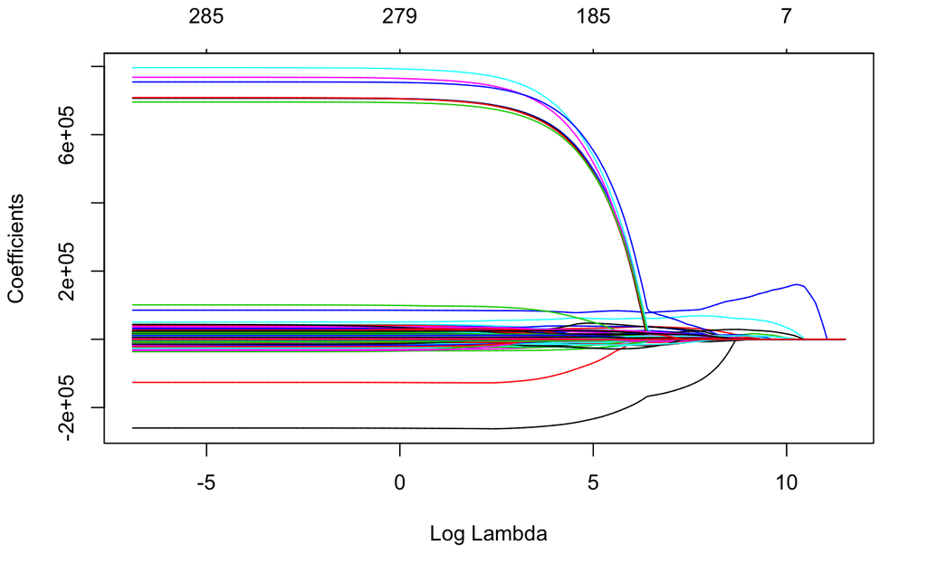

```r
library(glmnet)
lambdas <- 10^seq(5,-3,length=10000) #may take some time to run; results in better plot resolution
lasso.mod <- glmnet(x,y,alpha=1,lambda=lambdas)
plot(lasso.mod, xvar="lambda")
```

Lasso penalty performs variable selection, therefore it can be seen that many of the coefficients are reduced to zero when lambda is large (it can be hard to see this clearly because of the large number of coefficients).

### Tuning Parameter Selection

Use 80% of the provided training data (labeled data) for choosing the most optimal tuning parameter lambda. `cv.glmnet()` performs 10-fold cross-validation and provides lambda that results in the smallest cross-validation error (marked with red line on the plot). The other line (in black) marks the largest value of lambda such that error is within 1 SE of the minimum.

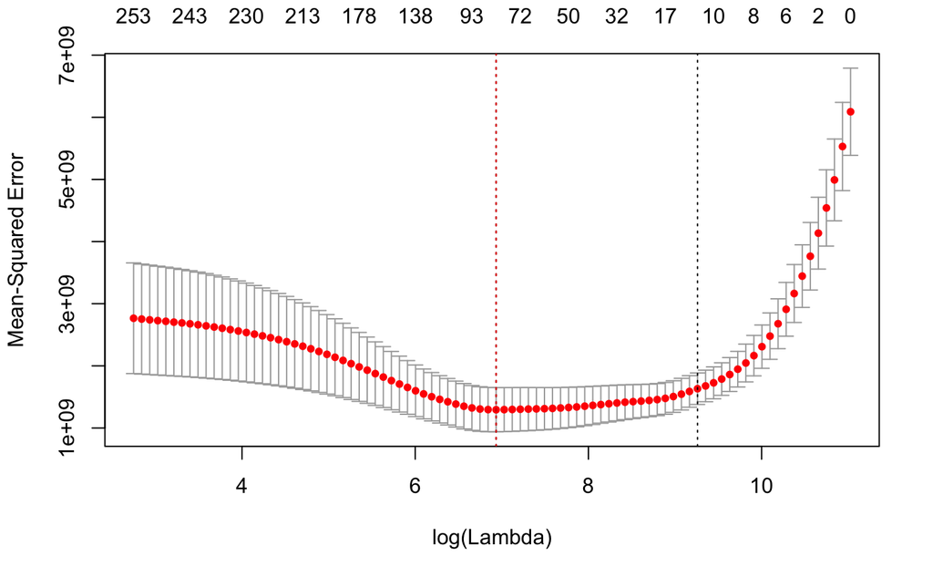

```r
train <- sample(nrow(data.train), nrow(data.train)*0.8)
cv.out <- cv.glmnet(x[train,],y[train],alpha=1)
best.lambda <- cv.out$lambda.min
plot(cv.out)
abline(v=log(best.lambda), col="red", lty=9)
```

```r
best.lambda
```

```
[1] 1027.054
```

*Note that results of `cv.glmnet()` are random, since folds are selected at random. The [‘glmnet’ Documentation](https://cran.r-project.org/web/packages/glmnet/glmnet.pdf) proposes a solution to this. The randomness can be reduced by running `cv.glmnet()` many times and averaging the result. I found that this randomness doesn’t have a significant effect on the end result (test RMSE is effectively unchanged).*

Plot standardized lasso coefficients as a function of ln(lambda) centered on the optimal value of lambda (marked by blue vertical line).

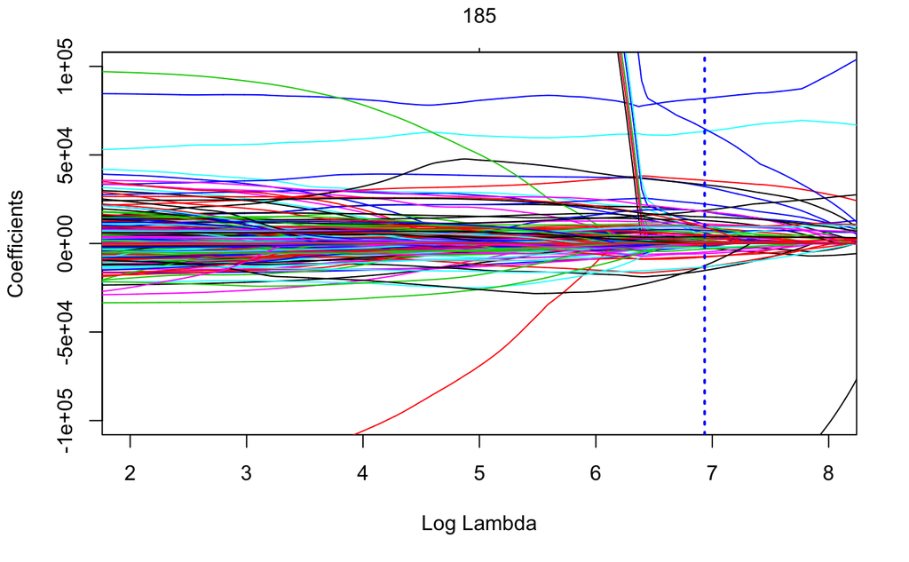

```r
plot(lasso.mod, xvar="lambda", xlim=c(2,8), ylim=c(-100000,100000))
abline(v=log(best.lambda), col="blue", lwd=2, lty=9)
```

As expected, for the best lambda lasso yields a sparse model (many of the coefficients are reduced to zero).

### Sanity Check

```r
coef <- predict(lasso.mod,type="coefficients",s=best.lambda, exact=T, x=x[train,], y=y[train])
coef.nonzero <- coef[as.vector(coef)>0,]
length(coef.nonzero)
```

```
[1] 55
```

```r
coef.nonzero
```

```
            LotArea          StreetPave      LandContourLvl    LotConfigCulDSac NeighborhoodClearCr
           0.325268         1815.495545         4172.308368         9995.231722         4063.748060
NeighborhoodCrawfor NeighborhoodNoRidge NeighborhoodNridgHt NeighborhoodSomerst NeighborhoodStoneBr
       20565.430834        37534.467426        19845.290063         6425.776950        20775.420097
NeighborhoodVeenker      Condition1Norm    HouseStyle1Story       OverallQual.L       OverallQual.Q
        2611.587022         6809.307163         3997.699344        85612.594263        60581.149031
      OverallCond.L       OverallCond^5           YearBuilt        YearRemodAdd     RoofMatlCompShg
       30946.173209         1232.957312          109.117089           65.066682        14904.375581
    RoofMatlMembran     RoofMatlWdShngl  Exterior1stBrkFace  Exterior2ndCmentBd  Exterior2ndImStucc
        8436.582477        95739.201385        14781.058192         6721.629912        11880.380156
         MasVnrArea         ExterQual.L          BsmtQual.L          BsmtQual.Q          BsmtQual.C
          13.760520         7048.042837        17899.816627         6701.561233        11953.105679
         BsmtCond^5      BsmtExposure.L      BsmtExposure.Q      BsmtFinType1.L      BsmtFinType1^4
         512.917874        10374.209528         6293.991586        11377.959727         1966.486244
        HeatingQC.L         HeatingQC.Q         CentralAirY           GrLivArea        BsmtFullBath
        4110.606919         1065.880595         1665.538350           40.393443         3850.045028
           FullBath       KitchenQual.Q       KitchenQual.C        TotRmsAbvGrd        Functional.L
        6058.414958        18976.548249         4425.616895          776.420717        20206.450800
       Functional^4          Fireplaces    GarageTypeAttchd      GarageFinish.Q          GarageCars
        1057.711641         4481.335943          178.162923          188.024989        10021.541940
         WoodDeckSF          X3SsnPorch         ScreenPorch         SaleTypeCon         SaleTypeNew
           7.441764           19.305675           17.734009        10816.501110        14051.041640
```

It is possible to check subjectively if the selection makes sense.

*Note that I don’t claim that variables selected by the lasso are **the only important variables** in the dataset. It is possible that there are pairs of highly collinear predictors in the dataset, and the lasso picks only one of them at random.*

### Model Testing

The other 20% of the data that was held out from model training are used to test how well the model performs for a chosen lambda.

```r
val <- -train
pred.val <- predict(lasso.mod,s=best.lambda ,newx=x[val,], exact=T, x=x[train,], y=y[train])
```

Compute test set mean-square error (MSE).

```r
mean((pred.val-y[val])^2)
```

```
[1] 695532591
```

Compute the fraction of (null) deviance explained by the full model (good approximation of R^2). This linear model does a pretty good job of explaining the variability of the training data (high fraction of variance explained).

```r
lasso.mod$dev.ratio[which.min(abs(lasso.mod$lambda-best.lambda))]
```

```
[1] 0.8918716
```

Compute the test set bias.Positive bias means that the model tends to overestimate the price. Negative bias means that the model tends to underestimate the price.

```r
mean(pred.val-y[val])
```

```
[1] -2653.943
```

Compute maximum deviation. The worst prediction made by the model is off by this amount in dollars.

```r
max(abs(pred.val-y[val]))
```

```
[1] 173434.2
```

Compute mean absolute deviation. On average, predictions are off by this amount in dollars.

```r
mean(abs(pred.val-y[val]))
```

```
[1] 15693.7
```

Compute root-mean-square error (RMSE) using natural logarithms of predicted and actual values (this is how Kaggle rates submissions).

```r
sqrt(mean((log(pred.val)-log(y[val]))^2))
```

```
[1] 0.117446
```

*Note that the RMSE on the actual unlabeled test dataset that is used in submission to Kaggle will be higher than what we got here. The unlabeled test set has about the same size as the training set, which makes it more likely to contain more outliers and high leverage points. Yet, computing RMSE using a hold out from a labeled dataset is a convenient technique for relative comparison of your own models. This way, there is no need to submit the predictions to get an estimate about the accuracy of your model.*

## Conclusion

A relatively good result (for a linear regression model) was achieved by simply making a few assumptions about the dataset, preprocessing it accordingly and using a lasso penalty to reduce the model’s variance.